# Project Python Foundations: FoodHub Data Analysis

**Marks: 40**

### Context

The number of restaurants in New York is increasing day by day. Lots of students and busy professionals rely on those restaurants due to their hectic lifestyles. Online food delivery service is a great option for them. It provides them with good food from their favorite restaurants. A food aggregator company FoodHub offers access to multiple restaurants through a single smartphone app.

The app allows the restaurants to receive a direct online order from a customer. The app assigns a delivery person from the company to pick up the order after it is confirmed by the restaurant. The delivery person then uses the map to reach the restaurant and waits for the food package. Once the food package is handed over to the delivery person, he/she confirms the pick-up in the app and travels to the customer's location to deliver the food. The delivery person confirms the drop-off in the app after delivering the food package to the customer. The customer can rate the order in the app. The food aggregator earns money by collecting a fixed margin of the delivery order from the restaurants.

### Objective

The food aggregator company has stored the data of the different orders made by the registered customers in their online portal. They want to analyze the data to get a fair idea about the demand of different restaurants which will help them in enhancing their customer experience. Suppose you are hired as a Data Scientist in this company and the Data Science team has shared some of the key questions that need to be answered. Perform the data analysis to find answers to these questions that will help the company to improve the business.

### Data Description

The data contains the different data related to a food order. The detailed data dictionary is given below.

### Data Dictionary

- order_id: Unique ID of the order
- customer_id: ID of the customer who ordered the food
- restaurant_name: Name of the restaurant
- cuisine_type: Cuisine ordered by the customer
- cost: Cost of the order
- day_of_the_week: Indicates whether the order is placed on a weekday or weekend (The weekday is from Monday to Friday and the weekend is Saturday and Sunday)
- rating: Rating given by the customer out of 5
- food_preparation_time: Time (in minutes) taken by the restaurant to prepare the food. This is calculated by taking the difference between the timestamps of the restaurant's order confirmation and the delivery person's pick-up confirmation.
- delivery_time: Time (in minutes) taken by the delivery person to deliver the food package. This is calculated by taking the difference between the timestamps of the delivery person's pick-up confirmation and drop-off information

### Let us start by importing the required libraries

```python
# to not display any waring
import warnings
warnings.filterwarnings('ignore')

# import libraries for data manipulation
import numpy as np
import pandas as pd

# import libraries for data visualization
import matplotlib.pyplot as plt
import seaborn as sns
```

### Understanding the structure of the data

```python
# read the data
df = pd.read_csv('foodhub_order.csv')
# returns the first 5 rows
df.head()
```

|  | order_id | customer_id | restaurant_name | cuisine_type | cost_of_the_order | day_of_the_week | rating | food_preparation_time | delivery_time |
| --- | --- | --- | --- | --- | --- | --- | --- | --- | --- |
| 0 | 1477147 | 337525 | Hangawi | Korean | 30.75 | Weekend | Not given | 25 | 20 |
| 1 | 1477685 | 358141 | Blue Ribbon Sushi Izakaya | Japanese | 12.08 | Weekend | Not given | 25 | 23 |
| 2 | 1477070 | 66393 | Cafe Habana | Mexican | 12.23 | Weekday | 5 | 23 | 28 |
| 3 | 1477334 | 106968 | Blue Ribbon Fried Chicken | American | 29.20 | Weekend | 3 | 25 | 15 |
| 4 | 1478249 | 76942 | Dirty Bird to Go | American | 11.59 | Weekday | 4 | 25 | 24 |

#### Observations:

The DataFrame has 9 columns as mentioned in the Data Dictionary. Data in each row corresponds to the order placed by a customer.

### **Question 1:** Write the code to check the shape of the dataset and write your observations based on that. (0.5 mark)

```python
# write your code here
df.shape
```

```
(1898, 9)
```

#### Observations:

The dataset has 1898 rows, which is 1898 observations and 9 colunms, which is 9 variables.

### Question 2: Write the observations based on the below output from the info() method. (0.5 mark)

```python
# use info() to print a concise summary of the DataFrame
df.info()
```

```
<class 'pandas.core.frame.DataFrame'>
RangeIndex: 1898 entries, 0 to 1897
Data columns (total 9 columns):
 #   Column                 Non-Null Count  Dtype
---  ------                 --------------  -----
 0   order_id               1898 non-null   int64
 1   customer_id            1898 non-null   int64
 2   restaurant_name        1898 non-null   object
 3   cuisine_type           1898 non-null   object
 4   cost_of_the_order      1898 non-null   float64
 5   day_of_the_week        1898 non-null   object
 6   rating                 1898 non-null   object
 7   food_preparation_time  1898 non-null   int64
 8   delivery_time          1898 non-null   int64
dtypes: float64(1), int64(4), object(4)
memory usage: 133.6+ KB
```

#### Observations:

- All columns have 1898 observations.
- No missing information
- The data types are 1 float, 4 ints64, and 4 objects.
- Restaurant name, cuisine type, and day of the week have dtypes as object but they should be categorical variables.
- Rating is under object dtype. It would need to be changed to int64 to make it easy for future analysis.

### Question 3: 'restaurant_name', 'cuisine_type', 'day_of_the_week' are object types. Write the code to convert the mentioned features to 'category' and write your observations on the same. (0.5 mark)

```python
# coverting "objects" to "category" reduces the data space required to store the dataframe
# write the code to convert 'restaurant_name', 'cuisine_type', 'day_of_the_week' into categorical data
df['restaurant_name']= df.restaurant_name.astype('category')
df['cuisine_type']= df.cuisine_type.astype('category')
df['day_of_the_week']= df.day_of_the_week.astype('category')

# use info() to print a concise summary of the DataFrame
df.info()
```

```
<class 'pandas.core.frame.DataFrame'>
RangeIndex: 1898 entries, 0 to 1897
Data columns (total 9 columns):
 #   Column                 Non-Null Count  Dtype
---  ------                 --------------  -----
 0   order_id               1898 non-null   int64
 1   customer_id            1898 non-null   int64
 2   restaurant_name        1898 non-null   category
 3   cuisine_type           1898 non-null   category
 4   cost_of_the_order      1898 non-null   float64
 5   day_of_the_week        1898 non-null   category
 6   rating                 1898 non-null   object
 7   food_preparation_time  1898 non-null   int64
 8   delivery_time          1898 non-null   int64
dtypes: category(3), float64(1), int64(4), object(1)
memory usage: 102.7+ KB
```

#### Observations:

- The dtype of Now restaurant name, cuisine type, and date of the week is category.

### **Question 4:** Write the code to find the summary statistics and write your observations based on that. (1 mark)

```python
# write your code here
df.describe()
```

|  | order_id | customer_id | cost_of_the_order | food_preparation_time | delivery_time |
| --- | --- | --- | --- | --- | --- |
| count | 1.898000e+03 | 1898.000000 | 1898.000000 | 1898.000000 | 1898.000000 |
| mean | 1.477496e+06 | 171168.478398 | 16.498851 | 27.371970 | 24.161749 |
| std | 5.480497e+02 | 113698.139743 | 7.483812 | 4.632481 | 4.972637 |
| min | 1.476547e+06 | 1311.000000 | 4.470000 | 20.000000 | 15.000000 |
| 25% | 1.477021e+06 | 77787.750000 | 12.080000 | 23.000000 | 20.000000 |
| 50% | 1.477496e+06 | 128600.000000 | 14.140000 | 27.000000 | 25.000000 |
| 75% | 1.477970e+06 | 270525.000000 | 22.297500 | 31.000000 | 28.000000 |
| max | 1.478444e+06 | 405334.000000 | 35.410000 | 35.000000 | 33.000000 |

#### Observations:

- In 1898 observations, the average cost of the order is around 16.50 dollars, the minimum is 4.47 dollars, and the maximun is 35.41 dollars.
- The range of cost of the order is 4.47 dollars to 35.41 dollars which is 30.94 dollars different.
- The average of food prep time is around 27 mins, min is 20 mins, and max is 35 mins which is 15 minutes different.
- The average delivery time is 24 mins, min 15 mins, and max is 33 mins which is 18 minutes different.

### **Question 5:** How many orders are not rated? (0.5 mark)

```python
#to count how many of each rating in the dataset
df.value_counts('rating')
```

```
rating
Not given    736
5            588
4            386
3            188
dtype: int64
```

#### Observations:

- There are 736 orders are not rated.
- In this dataset, there are 4 types of rating, 3, 4, 5, and Not given.
- Not given has the higher number of rating counts which is 736.
- 5 is the second highest, which is 588 and follow with 4, which is 386.
- 3 is the lowest number of voting counts, which is 188.
- Should explore more about those orders that received 'Not given'.

### Exploratory Data Analysis (EDA)

### **Question 6:** Explore all the variables and provide observations on the distributions of all the relevant variables in the dataset. (5 marks)

## Obervations on Restaurant Name

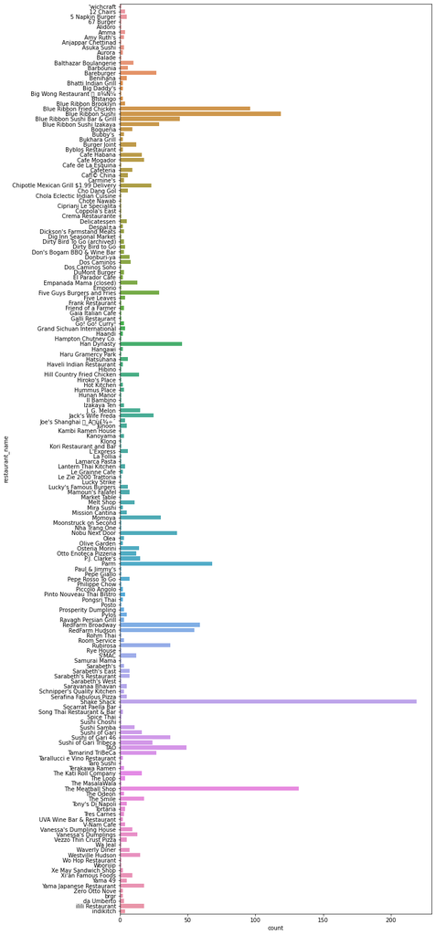

```python
plt.figure(figsize=(10,30))  # setting the figure size
sns.countplot(y="restaurant_name", data=df)
plt.savefig("output.jpg", bbox_inches ='tight')
```

#### Observation

- There is a few resturants have a significant high number of orders, especially the highest one.
- The highest number of orders is Shake Shake, follow by The Meatball Shop, Blue Ribbon Sushi, and Blue Ribbon Chicken in that order.
- Should find out if any variables correlation with have high number of orders. to improve the customer and restuarant experience.

```python
def histogram_boxplot(data, feature,figsize=(12, 7), kde=False, bins=None):
    """
    Boxplot and histogram combined

    data: dataframe
    feature: dataframe column
    figsize: size of figure (default (12,7))
    kde: whether to show the density curve (default False)
    bins: number of bins for histogram (default None)
    """
    f2, (ax_box2, ax_hist2) = plt.subplots(
        nrows=2,  # Number of rows of the subplot grid= 2
        sharex=True,  # x-axis will be shared among all subplots
        gridspec_kw={"height_ratios": (0.25, 0.75)},
        figsize=figsize,
    )  # creating the 2 subplots
    sns.boxplot(
        data=data, x=feature, ax=ax_box2, showmeans=True, color="violet"
    )  # boxplot will be created and a star will indicate the mean value of the column
    sns.histplot(
        data=data, x=feature, kde=kde, ax=ax_hist2, bins=bins, palette="winter"
    ) if bins else sns.histplot(
        data=data, x=feature, kde=kde, ax=ax_hist2
    )  # For histogram
    ax_hist2.axvline(
        data[feature].mean(), color="yellow", linestyle="-"
    )  # Add mean to the histogram
    ax_hist2.axvline(
        data[feature].median(), color="black", linestyle="--"
    )  # Add median to the histogram
```

## Observations on Order ID

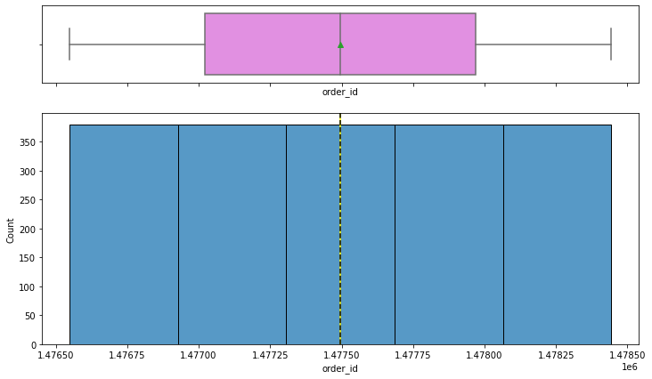

```python
histogram_boxplot(df, 'order_id',figsize=(12, 7), kde=False, bins=5 )
plt.savefig("output.jpg", bbox_inches ='tight')
```

## Obervations on Customer ID

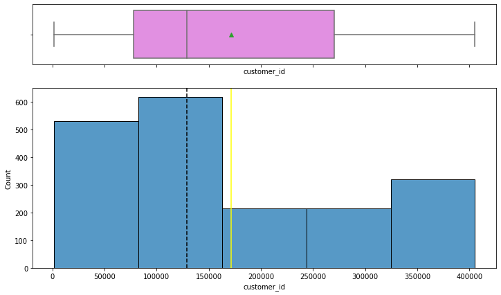

```python
histogram_boxplot(df, 'customer_id',figsize=(12, 7), kde=False, bins=5 )
plt.savefig("output.jpg", bbox_inches ='tight')
```

## Obervations on Cuisine Type

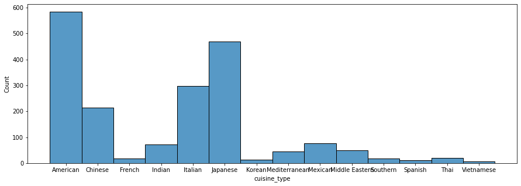

```python
plt.figure(figsize=(15,5))  # setting the figure size
sns.histplot(df['cuisine_type']);
plt.savefig("output.jpg", bbox_inches ='tight')
```

#### Observations:

- Top 5 cuirsine types in this dataset are American, Japanese, Italian, Chinese, and Maxican
- The rest of cuisines have very small amount of order comparing to the top 4
- Need to observe between top restuarant and top cuisine types to see thier correlation

## Obervations on Cost of the Order

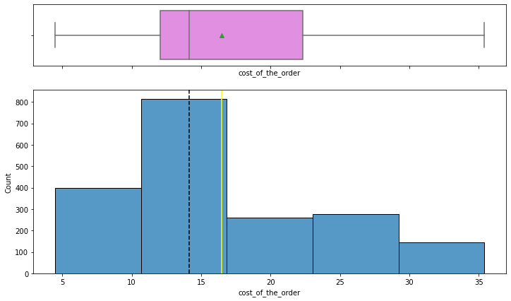

```python
histogram_boxplot(df, 'cost_of_the_order',figsize=(12, 7), kde=False, bins=5 )
plt.savefig("output.jpg", bbox_inches ='tight')
```

#### Observations:

- The distribution of the bill is right skewed.
- Majority of the the bills is on the left.
- Median is ~14 but the mean is ~16.
- There is no outliers in this variable
- We could observe more if there are any variables correlation could help to improve the total bill of orders.

## Obervations on Day of the Week

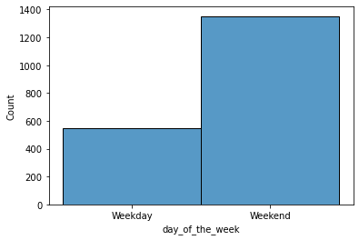

```python
sns.histplot(df['day_of_the_week']);
plt.savefig("output.jpg", bbox_inches ='tight')
```

#### Observations:

- The number of orders during weekend are more than double that of weekday

## Obervations on Rating

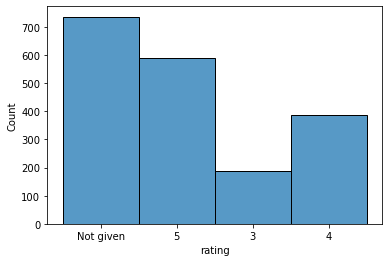

```python
sns.histplot(df['rating']);
plt.savefig("output.jpg", bbox_inches ='tight')
```

#### Observations:

- There are 4 types of ranting in this dataset. There are, Not Given,5 , 3, and 4.
- The highest numbers of rating is Not Given, then 5, 4, and 3.
- For further discovery, how to decrease Not Given rating so the company could figure out if customers are satisfied. If they are not, we can figure out how to improve the experience.
- Need to analyze which variables correlate to rating

## Obervations on Food Preperation Time

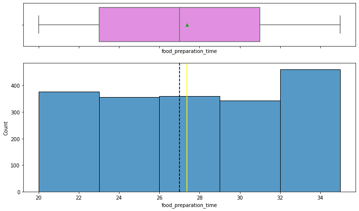

```python
histogram_boxplot(df, 'food_preparation_time',figsize=(12, 7), kde=False, bins=5 )
plt.savefig("output.jpg", bbox_inches ='tight')
```

#### Observations:

- The distribution of the food preperation time is slightly right skewed. It's almost a symmertrical distribution.
- In this dataset, it took at lest 20 minutes to prepare for each order.
- The maximum time to prepare for orders is around 35 minutes.
- The mean is higher than meanian by less than a minute.
- There is no outlines in this variable.

## Obervations on Delivery Time

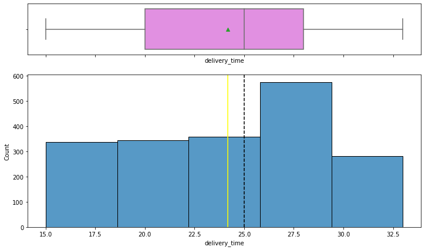

```python
histogram_boxplot(df, 'delivery_time',figsize=(12, 7), kde=False, bins=5 )
plt.savefig("output.jpg", bbox_inches ='tight')
```

### Question 7: Write the code to find the top 5 restaurants that have received the highest number of orders. (1 mark)

```python
# write the code here
rank = df.value_counts(['restaurant_name'])
rank.head() # result top 5 restaurants
```

```
restaurant_name
Shake Shack                  219
The Meatball Shop            132
Blue Ribbon Sushi            119
Blue Ribbon Fried Chicken     96
Parm                          68
dtype: int64
```

#### Observations:

- The top restaurant is Shake Shake with 219 orders. The number of orders is almost 100 orders more than the second restaurant, The Meatshop.
- The second, The Meatshop with 132 orders, and the third, Blue Ribbon Sushi with 119 orders.
- The fourth is Blue Ribbon Fried Chicken at 96 orders.
- The fifth is Parm with 68 orders.

### Question 8: Write the code to find the most popular cuisine on weekends. (1 mark)

```python
# write the code here
df.groupby(['restaurant_name'])['day_of_the_week'].value_counts().sort_values(ascending=False).head(1)
```

```
restaurant_name  day_of_the_week
Shake Shack      Weekend            145
Name: day_of_the_week, dtype: int64
```

### Question 9: Write the code to find the number of total orders where the cost is above 20 dollars. What is the percentage of such orders in the dataset? (1 mark)

```python
# write the code here
# write the code here
len(df[(df['cost_of_the_order'] > 20)])# to find the total number of orders that is more than 20 dollars
```

```
555
```

```python
#to find percentage by the total number of orders that is more than 20 dollars divide by total orders.
#Then multiple the result with 100

percent = (len(df[(df['cost_of_the_order'] > 20)]) / (len(df['cost_of_the_order'])) )*100

print(percent) # to print percent of orders which is the cost is above 20 dollars.
round(percent,2) # to round float to two decimals.
```

```
29.24130663856691
```

```
29.24
```

#### Observations:

- There are 555 orders that the cost is above 20 dollars.
- The order that the cost is above 20 dollars is 29.24% from all orders.
- From this info, 70% of orders is less than 20 dollars.

### Question 10: Write the code to find the mean delivery time based on this dataset. (1 mark)

```python
# write the code here
ave_dt = df['delivery_time'].mean() #to find the mean of delivery time for all order
print(ave_dt) #to print the mean
round(ave_dt,2) #to round the number to 2 desimal
```

```
24.161749209694417
```

```
24.16
```

#### Observations:

- On average it takes 24 minutes to delivery from the restaurant to the customer's.

### Question 11: Suppose the company has decided to give a free coupon of 15 dollars to the customer who has spent the maximum amount on a single order. Write the code to find the ID of the customer along with the order details. (1 mark)

```python
df.groupby(['customer_id'])['cost_of_the_order'].max().sort_values(ascending=False).head(1)
```

```
customer_id
62359    35.41
Name: cost_of_the_order, dtype: float64
```

#### Observations:

- The customer id 62359 has ordered the maximum amount on a single order as 35.41 dollars.

### Question 12: Perform bivariate/multivariate analysis to explore relationships between the important variables in the dataset. (7 marks)

```python
#to create a new DataFrame to make sure it won't effect the original DataFrame
new_df = df.copy()
new_df.info() #to check dtype
```

```
<class 'pandas.core.frame.DataFrame'>
RangeIndex: 1898 entries, 0 to 1897
Data columns (total 9 columns):
 #   Column                 Non-Null Count  Dtype
---  ------                 --------------  -----
 0   order_id               1898 non-null   int64
 1   customer_id            1898 non-null   int64
 2   restaurant_name        1898 non-null   category
 3   cuisine_type           1898 non-null   category
 4   cost_of_the_order      1898 non-null   float64
 5   day_of_the_week        1898 non-null   category
 6   rating                 1898 non-null   object
 7   food_preparation_time  1898 non-null   int64
 8   delivery_time          1898 non-null   int64
dtypes: category(3), float64(1), int64(4), object(1)
memory usage: 102.7+ KB
```

```python
new_df.head() #to return the first 5 data
```

|  | order_id | customer_id | restaurant_name | cuisine_type | cost_of_the_order | day_of_the_week | rating | food_preparation_time | delivery_time |
| --- | --- | --- | --- | --- | --- | --- | --- | --- | --- |
| 0 | 1477147 | 337525 | Hangawi | Korean | 30.75 | Weekend | Not given | 25 | 20 |
| 1 | 1477685 | 358141 | Blue Ribbon Sushi Izakaya | Japanese | 12.08 | Weekend | Not given | 25 | 23 |
| 2 | 1477070 | 66393 | Cafe Habana | Mexican | 12.23 | Weekday | 5 | 23 | 28 |
| 3 | 1477334 | 106968 | Blue Ribbon Fried Chicken | American | 29.20 | Weekend | 3 | 25 | 15 |
| 4 | 1478249 | 76942 | Dirty Bird to Go | American | 11.59 | Weekday | 4 | 25 | 24 |

```python
# convert 'Not given' to null as Int dtype so we can use rating variable to analyze with other numerical variables
new_df.rating = pd.to_numeric(new_df.rating, errors='coerce').astype('Int64')
new_df.head()
```

|  | order_id | customer_id | restaurant_name | cuisine_type | cost_of_the_order | day_of_the_week | rating | food_preparation_time | delivery_time |
| --- | --- | --- | --- | --- | --- | --- | --- | --- | --- |
| 0 | 1477147 | 337525 | Hangawi | Korean | 30.75 | Weekend | <NA> | 25 | 20 |
| 1 | 1477685 | 358141 | Blue Ribbon Sushi Izakaya | Japanese | 12.08 | Weekend | <NA> | 25 | 23 |
| 2 | 1477070 | 66393 | Cafe Habana | Mexican | 12.23 | Weekday | 5 | 23 | 28 |
| 3 | 1477334 | 106968 | Blue Ribbon Fried Chicken | American | 29.20 | Weekend | 3 | 25 | 15 |
| 4 | 1478249 | 76942 | Dirty Bird to Go | American | 11.59 | Weekday | 4 | 25 | 24 |

```python
#to convert <NA> to number 0 so we can analyze more.
new_df['rating'] = new_df['rating'].replace(np.nan, 0)
new_df1 = new_df.copy()
new_df1.head()
```

|  | order_id | customer_id | restaurant_name | cuisine_type | cost_of_the_order | day_of_the_week | rating | food_preparation_time | delivery_time |
| --- | --- | --- | --- | --- | --- | --- | --- | --- | --- |
| 0 | 1477147 | 337525 | Hangawi | Korean | 30.75 | Weekend | 0 | 25 | 20 |
| 1 | 1477685 | 358141 | Blue Ribbon Sushi Izakaya | Japanese | 12.08 | Weekend | 0 | 25 | 23 |
| 2 | 1477070 | 66393 | Cafe Habana | Mexican | 12.23 | Weekday | 5 | 23 | 28 |
| 3 | 1477334 | 106968 | Blue Ribbon Fried Chicken | American | 29.20 | Weekend | 3 | 25 | 15 |
| 4 | 1478249 | 76942 | Dirty Bird to Go | American | 11.59 | Weekday | 4 | 25 | 24 |

```python
new_df1.info() #to check dtype on rating.
```

```
<class 'pandas.core.frame.DataFrame'>
RangeIndex: 1898 entries, 0 to 1897
Data columns (total 9 columns):
 #   Column                 Non-Null Count  Dtype
---  ------                 --------------  -----
 0   order_id               1898 non-null   int64
 1   customer_id            1898 non-null   int64
 2   restaurant_name        1898 non-null   category
 3   cuisine_type           1898 non-null   category
 4   cost_of_the_order      1898 non-null   float64
 5   day_of_the_week        1898 non-null   category
 6   rating                 1898 non-null   Int64
 7   food_preparation_time  1898 non-null   int64
 8   delivery_time          1898 non-null   int64
dtypes: Int64(1), category(3), float64(1), int64(4)
memory usage: 104.6 KB
```

## Correlation

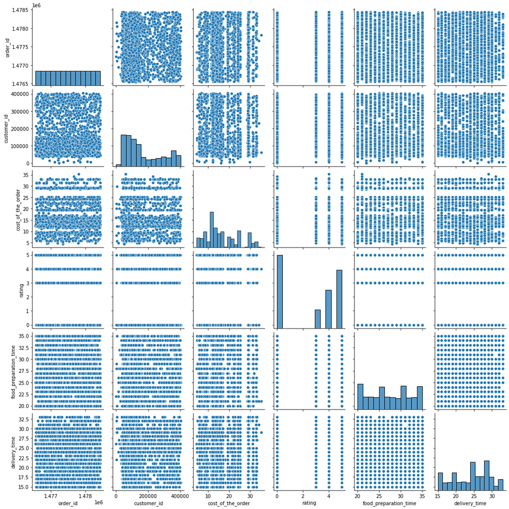

```python
# to create a pairplot for multivariate analysis for any correlation.
# Note that 'Not given' has converted it to 0 so it will show on the graph.
sns.pairplot(new_df1)
plt.savefig("output.jpg", bbox_inches ='tight')
```

#### Observations:

- Rating does not have any correlation to cost of the order, total delivery time.
- Data of cost of the order spreadouts out through total delivery time and customer id.
- Over all, there is no significant correlation between order id, customer id, cost of order, rating, food preperation time, and delivery time.

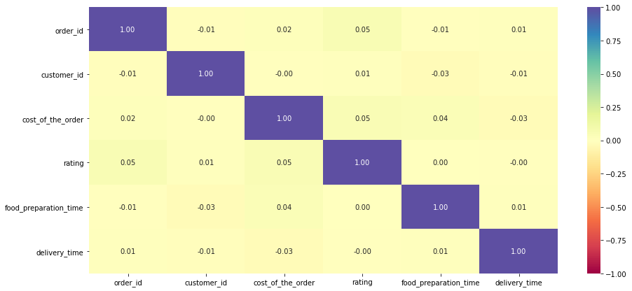

```python
# To check for correlation among numerical variables by using heatmap

num_var = ['order_id','customer_id','cost_of_the_order','rating','food_preparation_time', 'delivery_time']

corr_num_var = new_df1[num_var].corr()

# plot the heatmap

plt.figure(figsize=(15, 7))
sns.heatmap(corr_num_var, annot=True, vmin=-1, vmax=1, fmt=".2f", cmap="Spectral", xticklabels=corr_num_var.columns, yticklabels=corr_num_var.columns)
plt.show()
plt.savefig("output.jpg", bbox_inches ='tight')
```

```python
corr_num_var # the same inforamtion with graph above
```

|  | order_id | customer_id | cost_of_the_order | rating | food_preparation_time | delivery_time |
| --- | --- | --- | --- | --- | --- | --- |
| order_id | 1.000000 | -0.013960 | 0.021171 | 0.054700 | -0.007026 | 0.009690 |
| customer_id | -0.013960 | 1.000000 | -0.001322 | 0.009834 | -0.030330 | -0.009885 |
| cost_of_the_order | 0.021171 | -0.001322 | 1.000000 | 0.049531 | 0.041527 | -0.029949 |
| rating | 0.054700 | 0.009834 | 0.049531 | 1.000000 | 0.001156 | -0.003888 |
| food_preparation_time | -0.007026 | -0.030330 | 0.041527 | 0.001156 | 1.000000 | 0.011094 |
| delivery_time | 0.009690 | -0.009885 | -0.029949 | -0.003888 | 0.011094 | 1.000000 |

### Observations:

- Rating variable does not seems to have any correlation all numerical variables: order id, customer id, cost of the order, food preperation time and delivery time.
- Data in the cost of the order variable seems to spreadouts out when comparing to total delivery time and customer id.
- Over all, there is no significant correlation between order id, customer id, cost of order, rating, food preperation time, and delivery time.

### Relationship between customer experience (rating) and other type of variables

#### Note: for the graphs below, the rating 0 is 'Not given'.

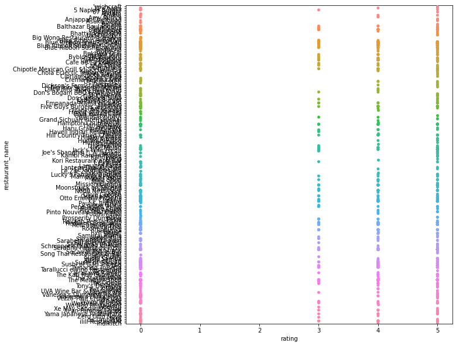

```python
# to check the relationship between restaurant and rating
plt.figure(figsize=(10,10))  # setting the figure size
sns.stripplot(data=new_df1, x ='rating', y= 'restaurant_name', jitter=True) # note that rating 0 is 'Not given'
plt.savefig("output.jpg", bbox_inches ='tight')
```

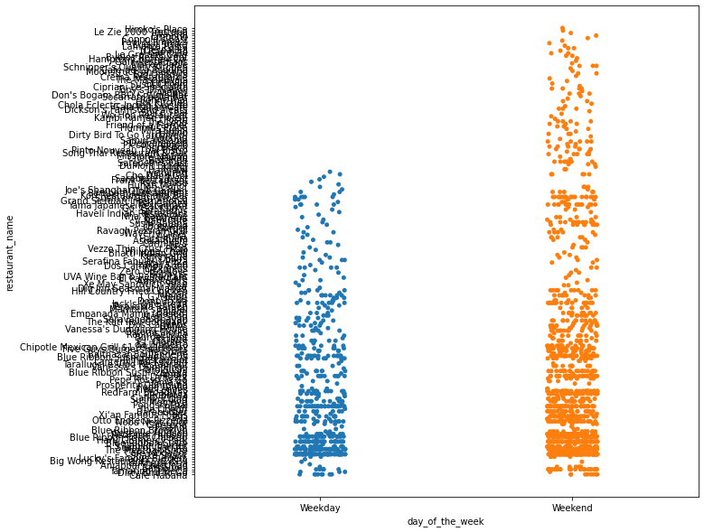

```python
# to compare between day of the week and restaurant
plt.figure(figsize=(10,10))  # setting the figure size
sns.stripplot(data=new_df1, x='day_of_the_week', y = 'restaurant_name', jitter = True)
plt.savefig("output.jpg", bbox_inches ='tight')
```

Weekend has more orders than weekdays. Some restaurants received more order than other. However, the trand of number of orders for restuarants on weekday and weekend are simmilar.

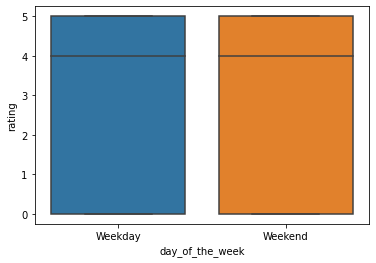

```python
sns.boxplot(data=new_df1, x = 'day_of_the_week', y = 'rating');
plt.savefig("output.jpg", bbox_inches ='tight')
```

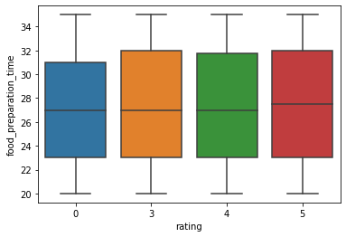

```python
## to see the relationship between food preparation time and rating
sns.boxplot(data=new_df1, x = 'rating', y = 'food_preparation_time');
plt.savefig("output.jpg", bbox_inches ='tight')
```

There is not much different in rating for different food preperation times.

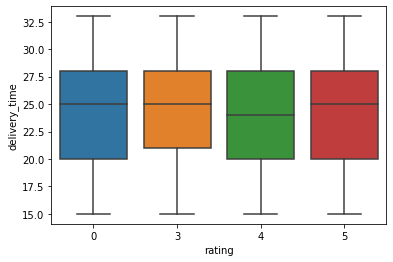

```python
# to see the relationship between delievery time and rating
sns.boxplot(data=new_df1, x = 'rating', y = 'delivery_time');
plt.savefig("output.jpg", bbox_inches ='tight')
```

There is not much different in rating for different delivery times as well. Need to do more analysis if rating would effect by for total time from when a customer place an order to receive the order.

```python
new = new_df1.copy() #create a new DataFrame
#to create a new column with 0 as data
total_time = 0
new['total_time'] = total_time

# to combine food prep and delivery time
sum_column = new["food_preparation_time"] + df["delivery_time"]
new['total_time'] = sum_column # add it to the total time column
new.head() # to return first 5 rows
```

|  | order_id | customer_id | restaurant_name | cuisine_type | cost_of_the_order | day_of_the_week | rating | food_preparation_time | delivery_time | total_time |
| --- | --- | --- | --- | --- | --- | --- | --- | --- | --- | --- |
| 0 | 1477147 | 337525 | Hangawi | Korean | 30.75 | Weekend | 0 | 25 | 20 | 45 |
| 1 | 1477685 | 358141 | Blue Ribbon Sushi Izakaya | Japanese | 12.08 | Weekend | 0 | 25 | 23 | 48 |
| 2 | 1477070 | 66393 | Cafe Habana | Mexican | 12.23 | Weekday | 5 | 23 | 28 | 51 |
| 3 | 1477334 | 106968 | Blue Ribbon Fried Chicken | American | 29.20 | Weekend | 3 | 25 | 15 | 40 |
| 4 | 1478249 | 76942 | Dirty Bird to Go | American | 11.59 | Weekday | 4 | 25 | 24 | 49 |

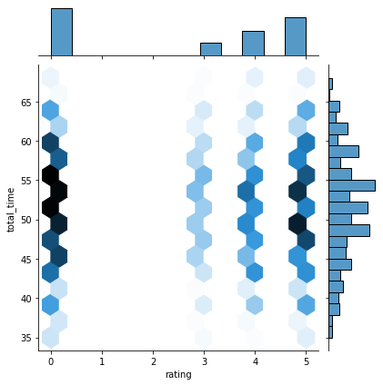

```python
sns.jointplot(data=new,x='rating', y='total_time', kind ='hex');
# to graph to identify if there is any correlation between rating and time
plt.savefig("output.jpg", bbox_inches ='tight')
```

Most of ratings are provided for the orders that have total time between 45-55 minutes. It seems that total time does not effect customer's rating much.

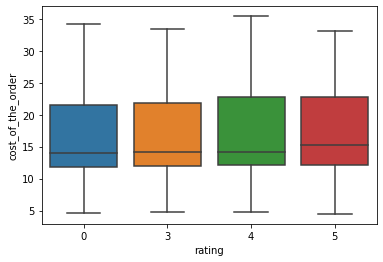

```python
sns.boxplot(data=new_df1, x = 'rating', y = 'cost_of_the_order');
plt.savefig("output.jpg", bbox_inches ='tight')
```

It seems that customers who ordered food cost around ~14 to ~15 dollars, provided the most number of ratings.

### Question 13: Suppose the company wants to provide a promotional offer in the advertisement of the restaurants. The condition to get the offer is that the restaurants must have a rating count of more than 50 and the average rating should be greater than 4. Write the code to find the restaurants fulfilling the criteria to get the promotional offer. (2 marks)

```python
# write the code here
new_df1 #to result of the DataFrame that convert rating 'Not given' to 0
```

|  | order_id | customer_id | restaurant_name | cuisine_type | cost_of_the_order | day_of_the_week | rating | food_preparation_time | delivery_time |
| --- | --- | --- | --- | --- | --- | --- | --- | --- | --- |
| 0 | 1477147 | 337525 | Hangawi | Korean | 30.75 | Weekend | 0 | 25 | 20 |
| 1 | 1477685 | 358141 | Blue Ribbon Sushi Izakaya | Japanese | 12.08 | Weekend | 0 | 25 | 23 |
| 2 | 1477070 | 66393 | Cafe Habana | Mexican | 12.23 | Weekday | 5 | 23 | 28 |
| 3 | 1477334 | 106968 | Blue Ribbon Fried Chicken | American | 29.20 | Weekend | 3 | 25 | 15 |
| 4 | 1478249 | 76942 | Dirty Bird to Go | American | 11.59 | Weekday | 4 | 25 | 24 |
| ... | ... | ... | ... | ... | ... | ... | ... | ... | ... |
| 1893 | 1476701 | 292602 | Chipotle Mexican Grill $1.99 Delivery | Mexican | 22.31 | Weekend | 5 | 31 | 17 |
| 1894 | 1477421 | 397537 | The Smile | American | 12.18 | Weekend | 5 | 31 | 19 |
| 1895 | 1477819 | 35309 | Blue Ribbon Sushi | Japanese | 25.22 | Weekday | 0 | 31 | 24 |
| 1896 | 1477513 | 64151 | Jack's Wife Freda | Mediterranean | 12.18 | Weekday | 5 | 23 | 31 |
| 1897 | 1478056 | 120353 | Blue Ribbon Sushi | Japanese | 19.45 | Weekend | 0 | 28 | 24 |

1898 rows × 9 columns

```python
# to drop all rows that receive 'Not given' as a rating which has converted them to 0.

new_df1 = new_df1.loc[(new_df1['rating'] > 0)]
data = new_df1
data
```

|  | order_id | customer_id | restaurant_name | cuisine_type | cost_of_the_order | day_of_the_week | rating | food_preparation_time | delivery_time |
| --- | --- | --- | --- | --- | --- | --- | --- | --- | --- |
| 2 | 1477070 | 66393 | Cafe Habana | Mexican | 12.23 | Weekday | 5 | 23 | 28 |
| 3 | 1477334 | 106968 | Blue Ribbon Fried Chicken | American | 29.20 | Weekend | 3 | 25 | 15 |
| 4 | 1478249 | 76942 | Dirty Bird to Go | American | 11.59 | Weekday | 4 | 25 | 24 |
| 5 | 1477224 | 147468 | Tamarind TriBeCa | Indian | 25.22 | Weekday | 3 | 20 | 24 |
| 7 | 1477859 | 89574 | Barbounia | Mediterranean | 5.97 | Weekday | 3 | 33 | 30 |
| ... | ... | ... | ... | ... | ... | ... | ... | ... | ... |
| 1889 | 1478190 | 94152 | RedFarm Broadway | Chinese | 8.68 | Weekday | 3 | 33 | 30 |
| 1890 | 1477316 | 164776 | TAO | Japanese | 15.67 | Weekend | 5 | 20 | 22 |
| 1893 | 1476701 | 292602 | Chipotle Mexican Grill $1.99 Delivery | Mexican | 22.31 | Weekend | 5 | 31 | 17 |
| 1894 | 1477421 | 397537 | The Smile | American | 12.18 | Weekend | 5 | 31 | 19 |
| 1896 | 1477513 | 64151 | Jack's Wife Freda | Mediterranean | 12.18 | Weekday | 5 | 23 | 31 |

1162 rows × 9 columns

```python
#to find averate for each restaurant
ave_rating = data.groupby(['restaurant_name'])['rating'].mean().sort_values(ascending=False).reset_index()
ave_rating
```

|  | restaurant_name | rating |
| --- | --- | --- |
| 0 | 'wichcraft | 5.0 |
| 1 | Ravagh Persian Grill | 5.0 |
| 2 | Chola Eclectic Indian Cuisine | 5.0 |
| 3 | Chote Nawab | 5.0 |
| 4 | Junoon | 5.0 |
| ... | ... | ... |
| 173 | Rohm Thai | <NA> |
| 174 | Room Service | <NA> |
| 175 | Spice Thai | <NA> |
| 176 | Tarallucci e Vino Restaurant | <NA> |
| 177 | Wa Jeal | <NA> |

178 rows × 2 columns

```python
#to change column'rating' to 'ave_rating'
ave_rating=ave_rating.rename(columns={'rating':'ave_rating'})
ave_rating.head()
```

|  | restaurant_name | ave_rating |
| --- | --- | --- |
| 0 | 'wichcraft | 5.0 |
| 1 | Ravagh Persian Grill | 5.0 |
| 2 | Chola Eclectic Indian Cuisine | 5.0 |
| 3 | Chote Nawab | 5.0 |
| 4 | Junoon | 5.0 |

```python
#to count how many rating each restaurant has received. Then sort the list dsecending
count = data.groupby(['restaurant_name'])['rating'].count().sort_values(ascending=False).reset_index()
#to change column'rating' to 'rating_count'
count = count.rename(columns={'rating':'rating_count'})
count
```

|  | restaurant_name | rating_count |
| --- | --- | --- |
| 0 | Shake Shack | 133 |
| 1 | The Meatball Shop | 84 |
| 2 | Blue Ribbon Sushi | 73 |
| 3 | Blue Ribbon Fried Chicken | 64 |
| 4 | RedFarm Broadway | 41 |
| ... | ... | ... |
| 173 | Market Table | 0 |
| 174 | Paul & Jimmy's | 0 |
| 175 | Room Service | 0 |
| 176 | Rohm Thai | 0 |
| 177 | Lamarca Pasta | 0 |

178 rows × 2 columns

```python
df_merge = ave_rating.merge(count, on = 'restaurant_name', how = 'inner')
df_merge.head()
```

|  | restaurant_name | ave_rating | rating_count |
| --- | --- | --- | --- |
| 0 | 'wichcraft | 5.0 | 1 |
| 1 | Ravagh Persian Grill | 5.0 | 1 |
| 2 | Chola Eclectic Indian Cuisine | 5.0 | 1 |
| 3 | Chote Nawab | 5.0 | 1 |
| 4 | Junoon | 5.0 | 3 |

```python
rating_50 = df_merge[df_merge['rating_count']>50]
rating_50
```

|  | restaurant_name | ave_rating | rating_count |
| --- | --- | --- | --- |
| 66 | The Meatball Shop | 4.511905 | 84 |
| 89 | Blue Ribbon Fried Chicken | 4.328125 | 64 |
| 93 | Shake Shack | 4.278195 | 133 |
| 101 | Blue Ribbon Sushi | 4.219178 | 73 |

```python
ave_4up = rating_50[rating_50['ave_rating']>4]
ave_4up
```

|  | restaurant_name | ave_rating | rating_count |
| --- | --- | --- | --- |
| 66 | The Meatball Shop | 4.511905 | 84 |
| 89 | Blue Ribbon Fried Chicken | 4.328125 | 64 |
| 93 | Shake Shack | 4.278195 | 133 |
| 101 | Blue Ribbon Sushi | 4.219178 | 73 |

#### Observations:

- There are 4 restaurants that have averate rating more than 4 and have number of rating count more than 50
  - The Meatball Shop averate rating of 4.511905 and 84 rating counts
  - Blue Ribbon Fried Chicken with averate rating of 4.328125 and 64 rating counts
  - Shake Shack with averate rating of 4.278195 and 133 rating counts
  - Blue Ribbon Sushi with averate rating of 4.219178 and 73 rating counts
- The Meatball Shop has the highest rating, 4.511905 and Shake Shack has the most rating counts, 133.

### Question 14: Suppose the company charges the restaurant 25% on the orders having cost greater than 20 dollars and 15% on the orders having cost greater than 5 dollars. Write the code to find the net revenue generated on all the orders given in the dataset. (2 marks)

```python
# write the code here
revenue = 0 #to create an empty column and named it 'revenue'
df['revenue'] = revenue #to add a 'revenue' column to df which is the original DataFrame
df.head()
```

|  | order_id | customer_id | restaurant_name | cuisine_type | cost_of_the_order | day_of_the_week | rating | food_preparation_time | delivery_time | revenue |
| --- | --- | --- | --- | --- | --- | --- | --- | --- | --- | --- |
| 0 | 1477147 | 337525 | Hangawi | Korean | 30.75 | Weekend | Not given | 25 | 20 | 0 |
| 1 | 1477685 | 358141 | Blue Ribbon Sushi Izakaya | Japanese | 12.08 | Weekend | Not given | 25 | 23 | 0 |
| 2 | 1477070 | 66393 | Cafe Habana | Mexican | 12.23 | Weekday | 5 | 23 | 28 | 0 |
| 3 | 1477334 | 106968 | Blue Ribbon Fried Chicken | American | 29.20 | Weekend | 3 | 25 | 15 | 0 |
| 4 | 1478249 | 76942 | Dirty Bird to Go | American | 11.59 | Weekday | 4 | 25 | 24 | 0 |

```python
df.info() #to check revenue dtype
```

```
<class 'pandas.core.frame.DataFrame'>
RangeIndex: 1898 entries, 0 to 1897
Data columns (total 10 columns):
 #   Column                 Non-Null Count  Dtype
---  ------                 --------------  -----
 0   order_id               1898 non-null   int64
 1   customer_id            1898 non-null   int64
 2   restaurant_name        1898 non-null   category
 3   cuisine_type           1898 non-null   category
 4   cost_of_the_order      1898 non-null   float64
 5   day_of_the_week        1898 non-null   category
 6   rating                 1898 non-null   object
 7   food_preparation_time  1898 non-null   int64
 8   delivery_time          1898 non-null   int64
 9   revenue                1898 non-null   int64
dtypes: category(3), float64(1), int64(5), object(1)
memory usage: 117.6+ KB
```

```python
cost=df.sort_values(by ='cost_of_the_order').reset_index() #to sort cost of order for an easy review
cost
```

|  | index | order_id | customer_id | restaurant_name | cuisine_type | cost_of_the_order | day_of_the_week | rating | food_preparation_time | delivery_time | revenue |
| --- | --- | --- | --- | --- | --- | --- | --- | --- | --- | --- | --- |
| 0 | 624 | 1477349 | 52327 | Nobu Next Door | Japanese | 4.47 | Weekend | 5 | 28 | 26 | 0 |
| 1 | 480 | 1476877 | 53289 | The Loop | Japanese | 4.66 | Weekend | Not given | 34 | 25 | 0 |
| 2 | 542 | 1477788 | 270444 | P.J. Clarke's | American | 4.71 | Weekend | Not given | 23 | 15 | 0 |
| 3 | 82 | 1477790 | 133617 | Shake Shack | American | 4.75 | Weekday | 4 | 35 | 28 | 0 |
| 4 | 1569 | 1477786 | 145389 | RedFarm Hudson | Chinese | 4.75 | Weekend | 3 | 23 | 25 | 0 |
| ... | ... | ... | ... | ... | ... | ... | ... | ... | ... | ... | ... |
| 1893 | 1370 | 1478329 | 116992 | Tres Carnes | Mexican | 33.32 | Weekday | 4 | 21 | 33 | 0 |
| 1894 | 1831 | 1476970 | 275689 | Nobu Next Door | Japanese | 33.37 | Weekend | 4 | 32 | 21 | 0 |
| 1895 | 1762 | 1477700 | 60039 | Blue Ribbon Sushi | Japanese | 33.37 | Weekday | 3 | 30 | 27 | 0 |
| 1896 | 1646 | 1477665 | 231061 | Han Dynasty | Chinese | 34.19 | Weekday | Not given | 21 | 31 | 0 |
| 1897 | 573 | 1477814 | 62359 | Pylos | Mediterranean | 35.41 | Weekday | 4 | 21 | 29 | 0 |

1898 rows × 11 columns

```python
cost5 = cost[cost['cost_of_the_order']<20] #to return orders that less than 20 dollars
cost5
```

|  | index | order_id | customer_id | restaurant_name | cuisine_type | cost_of_the_order | day_of_the_week | rating | food_preparation_time | delivery_time | revenue |
| --- | --- | --- | --- | --- | --- | --- | --- | --- | --- | --- | --- |
| 0 | 624 | 1477349 | 52327 | Nobu Next Door | Japanese | 4.47 | Weekend | 5 | 28 | 26 | 0 |
| 1 | 480 | 1476877 | 53289 | The Loop | Japanese | 4.66 | Weekend | Not given | 34 | 25 | 0 |
| 2 | 542 | 1477788 | 270444 | P.J. Clarke's | American | 4.71 | Weekend | Not given | 23 | 15 | 0 |
| 3 | 82 | 1477790 | 133617 | Shake Shack | American | 4.75 | Weekday | 4 | 35 | 28 | 0 |
| 4 | 1569 | 1477786 | 145389 | RedFarm Hudson | Chinese | 4.75 | Weekend | 3 | 23 | 25 | 0 |
| ... | ... | ... | ... | ... | ... | ... | ... | ... | ... | ... | ... |
| 1338 | 1448 | 1478317 | 128216 | Shake Shack | American | 19.74 | Weekday | 4 | 35 | 32 | 0 |
| 1339 | 39 | 1476891 | 220693 | Shake Shack | American | 19.89 | Weekend | Not given | 27 | 19 | 0 |
| 1340 | 48 | 1478354 | 52037 | Blue Ribbon Fried Chicken | American | 19.89 | Weekday | Not given | 27 | 24 | 0 |
| 1341 | 1339 | 1477720 | 215219 | Empanada Mama (closed) | Mexican | 19.98 | Weekday | 4 | 23 | 32 | 0 |
| 1342 | 974 | 1476851 | 361220 | Carmine's | Italian | 19.98 | Weekday | 5 | 34 | 30 | 0 |

1343 rows × 11 columns

```python
rev5_20 = cost5[cost5['cost_of_the_order']>5].reset_index() #to return orders that are more than 5 dollars
rev5_20
```

|  | level_0 | index | order_id | customer_id | restaurant_name | cuisine_type | cost_of_the_order | day_of_the_week | rating | food_preparation_time | delivery_time | revenue |
| --- | --- | --- | --- | --- | --- | --- | --- | --- | --- | --- | --- | --- |
| 0 | 9 | 1491 | 1477345 | 339144 | The Meatball Shop | Italian | 5.05 | Weekend | Not given | 29 | 19 | 0 |
| 1 | 10 | 1095 | 1477530 | 64754 | The Kati Roll Company | Indian | 5.34 | Weekend | 4 | 27 | 18 | 0 |
| 2 | 11 | 802 | 1476876 | 325285 | RedFarm Broadway | Chinese | 5.48 | Weekend | 3 | 27 | 18 | 0 |
| 3 | 12 | 1649 | 1477346 | 235620 | Shake Shack | American | 5.53 | Weekday | 4 | 28 | 26 | 0 |
| 4 | 13 | 601 | 1478055 | 7567 | indikitch | Indian | 5.58 | Weekend | Not given | 35 | 30 | 0 |
| ... | ... | ... | ... | ... | ... | ... | ... | ... | ... | ... | ... | ... |
| 1329 | 1338 | 1448 | 1478317 | 128216 | Shake Shack | American | 19.74 | Weekday | 4 | 35 | 32 | 0 |
| 1330 | 1339 | 39 | 1476891 | 220693 | Shake Shack | American | 19.89 | Weekend | Not given | 27 | 19 | 0 |
| 1331 | 1340 | 48 | 1478354 | 52037 | Blue Ribbon Fried Chicken | American | 19.89 | Weekday | Not given | 27 | 24 | 0 |
| 1332 | 1341 | 1339 | 1477720 | 215219 | Empanada Mama (closed) | Mexican | 19.98 | Weekday | 4 | 23 | 32 | 0 |
| 1333 | 1342 | 974 | 1476851 | 361220 | Carmine's | Italian | 19.98 | Weekday | 5 | 34 | 30 | 0 |

1334 rows × 12 columns

```python
rev5_20.tail() # to return the last 5 rows to double check on data
```

|  | level_0 | index | order_id | customer_id | restaurant_name | cuisine_type | cost_of_the_order | day_of_the_week | rating | food_preparation_time | delivery_time | revenue |
| --- | --- | --- | --- | --- | --- | --- | --- | --- | --- | --- | --- | --- |
| 1329 | 1338 | 1448 | 1478317 | 128216 | Shake Shack | American | 19.74 | Weekday | 4 | 35 | 32 | 0 |
| 1330 | 1339 | 39 | 1476891 | 220693 | Shake Shack | American | 19.89 | Weekend | Not given | 27 | 19 | 0 |
| 1331 | 1340 | 48 | 1478354 | 52037 | Blue Ribbon Fried Chicken | American | 19.89 | Weekday | Not given | 27 | 24 | 0 |
| 1332 | 1341 | 1339 | 1477720 | 215219 | Empanada Mama (closed) | Mexican | 19.98 | Weekday | 4 | 23 | 32 | 0 |
| 1333 | 1342 | 974 | 1476851 | 361220 | Carmine's | Italian | 19.98 | Weekday | 5 | 34 | 30 | 0 |

```python
#to calculate revenue for orders  between 5-20 dollars
rev5_20['revenue']= rev5_20['cost_of_the_order'].apply(lambda x: x*0.15)
#to return revenue for order between 5-20 dollars
rev5_20.head()
```

|  | level_0 | index | order_id | customer_id | restaurant_name | cuisine_type | cost_of_the_order | day_of_the_week | rating | food_preparation_time | delivery_time | revenue |
| --- | --- | --- | --- | --- | --- | --- | --- | --- | --- | --- | --- | --- |
| 0 | 9 | 1491 | 1477345 | 339144 | The Meatball Shop | Italian | 5.05 | Weekend | Not given | 29 | 19 | 0.7575 |
| 1 | 10 | 1095 | 1477530 | 64754 | The Kati Roll Company | Indian | 5.34 | Weekend | 4 | 27 | 18 | 0.8010 |
| 2 | 11 | 802 | 1476876 | 325285 | RedFarm Broadway | Chinese | 5.48 | Weekend | 3 | 27 | 18 | 0.8220 |
| 3 | 12 | 1649 | 1477346 | 235620 | Shake Shack | American | 5.53 | Weekday | 4 | 28 | 26 | 0.8295 |
| 4 | 13 | 601 | 1478055 | 7567 | indikitch | Indian | 5.58 | Weekend | Not given | 35 | 30 | 0.8370 |

```python
rev20 = df[df['cost_of_the_order']>20]
rev20 #to return orders that are more than 20 dollars
```

|  | order_id | customer_id | restaurant_name | cuisine_type | cost_of_the_order | day_of_the_week | rating | food_preparation_time | delivery_time | revenue |
| --- | --- | --- | --- | --- | --- | --- | --- | --- | --- | --- |
| 0 | 1477147 | 337525 | Hangawi | Korean | 30.75 | Weekend | Not given | 25 | 20 | 0 |
| 3 | 1477334 | 106968 | Blue Ribbon Fried Chicken | American | 29.20 | Weekend | 3 | 25 | 15 | 0 |
| 5 | 1477224 | 147468 | Tamarind TriBeCa | Indian | 25.22 | Weekday | 3 | 20 | 24 | 0 |
| 12 | 1476966 | 129969 | Blue Ribbon Fried Chicken | American | 24.30 | Weekend | 5 | 23 | 17 | 0 |
| 17 | 1477373 | 139885 | Blue Ribbon Sushi Izakaya | Japanese | 33.03 | Weekend | Not given | 21 | 22 | 0 |
| ... | ... | ... | ... | ... | ... | ... | ... | ... | ... | ... |
| 1884 | 1477437 | 304993 | Shake Shack | American | 31.43 | Weekend | 3 | 31 | 24 | 0 |
| 1885 | 1477550 | 97324 | Shake Shack | American | 29.05 | Weekday | 4 | 27 | 29 | 0 |
| 1892 | 1477473 | 97838 | Han Dynasty | Chinese | 29.15 | Weekend | Not given | 29 | 21 | 0 |
| 1893 | 1476701 | 292602 | Chipotle Mexican Grill $1.99 Delivery | Mexican | 22.31 | Weekend | 5 | 31 | 17 | 0 |
| 1895 | 1477819 | 35309 | Blue Ribbon Sushi | Japanese | 25.22 | Weekday | Not given | 31 | 24 | 0 |

555 rows × 10 columns

```python
#to calculate revenue for orders that are more than 20 dollars
rev20['revenue']=rev20['cost_of_the_order'].apply(lambda x: x*0.25)
rev20.head()
```

|  | order_id | customer_id | restaurant_name | cuisine_type | cost_of_the_order | day_of_the_week | rating | food_preparation_time | delivery_time | revenue |
| --- | --- | --- | --- | --- | --- | --- | --- | --- | --- | --- |
| 0 | 1477147 | 337525 | Hangawi | Korean | 30.75 | Weekend | Not given | 25 | 20 | 7.6875 |
| 3 | 1477334 | 106968 | Blue Ribbon Fried Chicken | American | 29.20 | Weekend | 3 | 25 | 15 | 7.3000 |
| 5 | 1477224 | 147468 | Tamarind TriBeCa | Indian | 25.22 | Weekday | 3 | 20 | 24 | 6.3050 |
| 12 | 1476966 | 129969 | Blue Ribbon Fried Chicken | American | 24.30 | Weekend | 5 | 23 | 17 | 6.0750 |
| 17 | 1477373 | 139885 | Blue Ribbon Sushi Izakaya | Japanese | 33.03 | Weekend | Not given | 21 | 22 | 8.2575 |

```python
#to calculate the total revenue for orders that between 5 to 20 dollars
t_rev5_20 =rev5_20['revenue'].sum()
round(t_rev5_20,2) #to round number to 2 decimals
```

```
2477.58
```

```python
#to calculate the total revenue for orders that more more than 20 dollars
t_rev20 =rev20['revenue'].sum()
round(t_rev20,2)
```

```
3688.73
```

```python
#to calculate the total revenue
total_rev = t_rev5_20 + t_rev20
print(total_rev)
round(total_rev,2)
```

```
6166.303
```

```
6166.3
```

### Question 15: Suppose the company wants to analyze the total time required to deliver the food. Write the code to find out the percentage of orders that have more than 60 minutes of total delivery time. (2 marks)

Note: The total delivery time is the summation of the food preparation time and delivery time.

```python
# write the code here
over60 = len(df[(df['delivery_time']+ df['food_preparation_time']>60)])
over60
```

```
200
```

```python
percent60 = (over60/len(df['order_id']))*100 # to calculate percentage of total delivery time is greater than 60 mins
print(percent60) #to print wthe percantage

round(percent60,2) # to round the percent to 2 decimals
```

```
10.537407797681771
```

```
10.54
```

#### Observations:

- There are 200 orders that took more than 60 minutes for food to be delivered.
- It's 10.54% of all orders.

### Question 16: Suppose the company wants to analyze the delivery time of the orders on weekdays and weekends. Write the code to find the mean delivery time on weekdays and weekends. Write your observations on the results. (2 marks)

```python
# write the code here
df.groupby('day_of_the_week')['delivery_time'].mean()
```

```
day_of_the_week
Weekday    28.340037
Weekend    22.470022
Name: delivery_time, dtype: float64
```

#### Observations:

- During weekdays, in average the delivery time is almost 29 mins
- During weekends, in averate the delivery time is almost 23 mins
- It's faster to delivery food during weekends

### Conclusion and Recommendations

### **Question 17:** Write the conclusions and business recommendations derived from the analysis. (3 marks)

#### Key Insights:

After analyzing the dataset from Foodhub of almost 1900 food delivery orders from restuarants thorughout New York. The dataset has monitized orders during weekday and weekend. Our interest is to understand which factors could improve customer expereience for customer retention and growth. In addition, we analyzed cost of the orders to learn insight on revenue.

Here is the summarry from the analysis:

#### Recommendation to business

1. There are correlation among the popular types of cusine and number orders from resturants. To collaberate with top 25 restuarants by:
   - creating promotion strategies to increase order counts
   - Sharing customer rating and feedback for any improvement
   - Sending coupons to customers from their most frequent restaurants on thier special days such as birthday
2. A great number of customers did not leave rating for thier orders. There is room to encourage customers to provide more rating and feedback in order to maximize oppertunities to enhance customer experience.
   - Offering an incentive to customers to encorage them to provide a rating per each order
   - creating an easy and convenient way for customers to provide rating and feedback
3. Most orders are less than 20 dollars but the company would make more revenue from an order greater than 20 dollars. To maximize revenue by:
   - Creating a campaing for a discount or a free appertizer if customers placed orders more than 35 dollars
   - Creating new policy for a 5 dollars minimum per order to avoid 0 dollar revenue
4. Since most of customers order food during weekends, there is room to increase more orders during weekdays by:
   - Offering promotion if order food during weekdays

## Further Analysis

1. To define detail on incentives and coupons that would be attractive to increase revenue and the customer base
2. To perfrom cost analysis and return on investment on modifing the app